# Complexity

DISEÑO Y ANÁLISIS DE ALGORITMOS

Walter Quispe Vargas

Docente - EAP Ciencia de la Computación - Universidad Continental

## Propósito de la Sesión

- Diseñar soluciones computacionales sencillas o aproximadas para problemas cuya resolución exacta no es eficiente, mediante el análisis de su complejidad algorítmica.
- Para problemas `difíciles`, muchas veces no se puede encontrar una solución óptima en tiempo razonable (`polinómico`). Entonces, lo que se hace en la práctica es:
  - Diseñar soluciones aproximadas o heurísticas que sean “rápidas” o sean soluciones “suficientemente buenas”.
  - Ejemplo: Traveling salesman problem (Problema del Viajante), dado un conjunto de ciudades, encontrar la ruta más corta que las visite todas una vez. Solución exacta: complejidad factorial ($O(n!)$). Solución aproximada: algoritmo *greedy* (siempre ir a la ciudad más cercana no visitada.)

## Contenidos a tratar

- *Complejidad Computacional (Algorítmica)*
- *Problemas P y NP*
- *Problemas NP-Completos y Reducciones*
- *Algoritmos de Aproximación*

## Complejidad Computacional

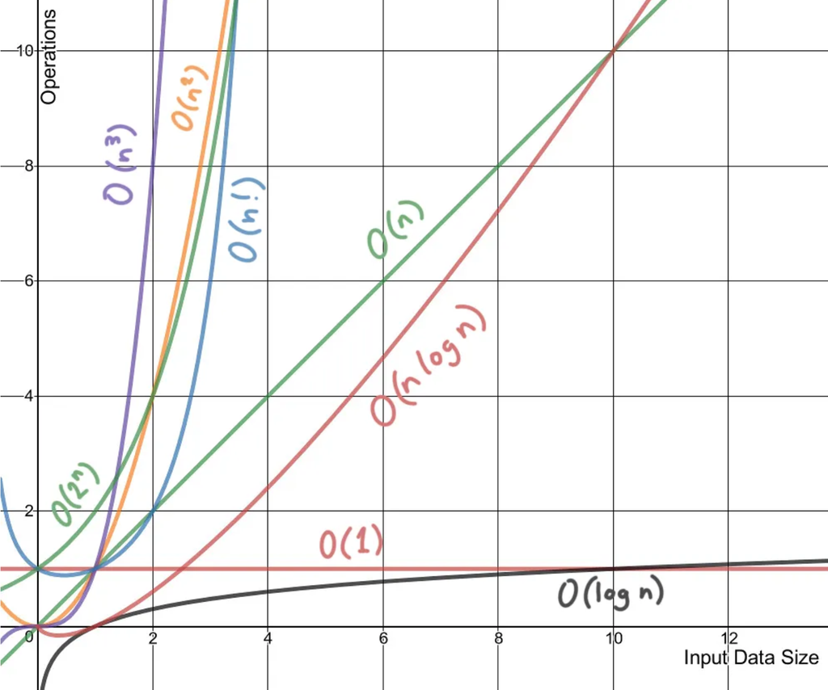

## Complejidad Computacional

- La complejidad algorítmica mide los recursos (*Tiempo* y *Espacio*) requeridos para ejecutar un algoritmo, en función del tamaño de la entrada (*n*).
- **TIME**: La complejidad temporal $T(n)$ de un algoritmo es su tiempo de ejecución (el número de operaciones requeridas)
- **SPACE**: La complejidad espacial de un algoritmo es la cantidad de memoria necesaria para su ejecución.
- **BIG-O**: Es la notación matemática que clasifica los algoritmos en función de sus requisitos de tiempo de ejecución o espacio a medida que crece el tamaño de la entrada $n$
- **Ejemplos**
  - Tiempo Constante: $O(1)$
  - Tiempo Logaritmico: $O(\log n)$
  - Tiempo Polinomial: $O(n^k)$
  - Tiempo Exponencial : $O(2^n)$

## Problemas P y NP

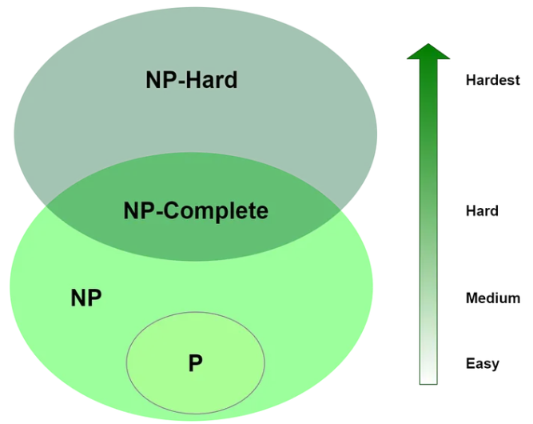

## Problemas P y NP

- $P\subseteq NP$: Todo problema que pertenece a la clase **P**, tambien pertenece a la clase **NP**.
- $P \neq NP$: El problema **P vs NP** fue planteado formalmente por Stephen Cook en 1971, en su artículo clásico: [The Complexity of Theorem-Proving Procedures](https://www.cs.toronto.edu/~sacook/homepage/1971.pdf).
  - En ese trabajo, Cook introdujo la noción de **NP-completitud** y formuló esencialmente la gran pregunta: `¿Todo problema cuya solución puede verificarse rápidamente también puede resolverse rápidamente?` ($NP\subseteq P$).
  - Además mostró que el problema de satisfacibilidad booleana **SAT** era el primero de ellos. Paralelamente Levin desarrollo ideas similares.

## Problemas NP-Completos

- **Teorema Cook-Levin** plantea que SAT es NP-completo, que es el punto de arranque de todo el problema.
- SAT: `¿Existe alguna asignación de valores (verdadero/falso) a variables booleanas que haga verdadera una fórmula lógica?`
  - Supón la fórmula: $(x \vee y) \wedge (\lnot x \vee z)$ -La pregunta es: ¿puedes elegir valores para $x,y,z$ que hagan toda la expresión verdadera?
  - Solución: $x=V, y=F, z=V$, la formula se vuelve verdadera, entonces es satisfacible.
  - Pero: $(x)\wedge(\lnot x)$ no importa el valor de $x$ es insatisfacible.
- SAT suele expresarse en Forma Normal Conjuntiva (CNF): Cada cláusula es una disyunción (OR) de literales (proposiciones atómicas). $(clausula_1)\wedge (clausula_2)\wedge...$
  - 3SAT es el problema SAT pero cada cláusula tiene exactamente 3 literales. $(x\vee\lnot y \vee z) \wedge (\lnot x \vee y \vee w)$
  - SAT general cláusulas de cualquier tamaño
  - 2SAT máximo 2 literales (fácil, está en $P$)
  - 3SAT exactamente 3 literales (difícil, $NP-completo$)

## Reducciones

- `Reducción`: Una reducción es transformar un problema en otro de forma que: si sabes resolver el segundo, automáticamente resuelves el primero
  - $A\leq_p B$: Decimos que un problema $A$ se reduce a otro $B$ si: Puedes transformar cualquier instancia de $A$ en una instancia de $B$, la transformación es rápida (tiempo polinómico)
  - Ejemplo: Problema A: “resolver sudoku”. Problema B: “resolver SAT”, Si conviertes cualquier sudoku en una fórmula SAT, Sudoku $\leq_p$ SAT, entonces: Si tienes un algoritmo rápido para SAT puedes resolver sudoku rápido.
- Para demostrar que un problema $X$ es NP-completo: Tomas un problema ya conocido (como SAT), Lo reduces a $X$, Concluyes: $X$ es tan difícil como SAT
  - $SAT\leq_p3SAT$ Puedes convertir cualquier SAT en 3SAT, Entonces 3SAT es igual de difícil.

## Algoritmos Aproximados

- Algoritmos Aproximados para problemas *NP-Completos*
- Muchos problemas NP-completos no pueden resolverse eficientemente de manera exacta para entradas grandes.
- Los algoritmos aproximados buscan:
  - Encontrar soluciones rápidas.
  - Garantizar qué tan cerca están del óptimo.
  - Sacrificar exactitud por eficiencia.
- Se trabaja especialmente con problemas de optimización:
  - Minimización: costo lo más pequeño posible.
  - Maximización: beneficio lo más grande posible.
- Razón de Aproximación en Algoritmos Aproximados.
  - Es una medida que indica qué tan buena es la solución producida por un algoritmo aproximado comparada con la solución óptima.
  - Para minimización se define:
    $$\rho(n)=\frac{C}{C^*}$$
  - $C$: es el costo obtenido por el algoritmo aproximado.
  - $C^*$: es el costo óptimo verdadero.
  - Como el óptimo es el menor posible $C\geq C^*$, entonces
    $$\rho(n)\geq 1$$
- Regla Heuristica:

| Razón | Significado |
| --- | --- |
| 1 | solución perfecta |
| 1.1 | máximo 10% peor |
| 2 | máximo el doble |
| 5 | puede ser hasta 5 veces peor |

- Mientras más cerca de 1 mejor el algoritmo aproximado.
- Para problemas de maximización:
  $$\rho(n)=\frac{C^*}{C}$$
- **PTAS** y **FPTAS** en Algoritmos Aproximados
  - los conceptos PTAS (polinomial-time approximation scheme) y FPTAS (full polinomial-time approximation scheme) describen familias de algoritmos aproximados que pueden producir soluciones extremadamente cercanas al óptimo.
  - Un PTAS es una familia de algoritmos que, para cualquier: $\epsilon > 0$ encuentra una solución con razón de aproximación: $1+\epsilon$ en tiempo polinómico respecto al tamaño de entrada.

## Simuladores Visuales

- [Traveling Salesman Problem 1](https://algorithms.discrete.ma.tum.de/graph-games/tsp-game/index_en.html)
- [Traveling Salesman Problem 2](https://www.math.uwaterloo.ca/tsp/)
- [Visualizing Algorithms USFCA](https://www.cs.usfca.edu/~galles/visualization/)
- [Visualgo](https://visualgo.net/en)

## ¿Qué aprendimos hoy?

- *Complejidad Computacional*
- *Problemas P y NP*
- *Problemas NP-Completos y Reducciones*
- *Algoritmos de Aproximación*

## Referencias Bibliografícas

- *Cormen, T. H., Leiserson, C. E., Rivest, R. L., & Stein, C. (2022). Introduction to Algorithms (4th ed.). The MIT Press.*
  - Capítulo 34 *NP-Completeness*
  - Capítulo 35 *Approximation Algorithms*

## PREGUNTAS…

[figure not shown]